# *Homework 11*

# **Incluindo efeitos de interação GE nos modelos de seleção genômica**

#### **Germano Martins F. Costa Neto**

##### Data: July 06th, 2018

```r
pkg <- c("breedR","snpReady","BGGE","knitr","kableExtra","PerformanceAnalytics","reshape2","plyr","tidyr","ggplot2","GenABEL")

if (length(setdiff(pkg, rownames(installed.packages()))) > 0) {
  install.packages(setdiff(pkg, rownames(installed.packages())))}
sapply(pkg,library,character.only = TRUE)
```

[output not shown]

[output cut: 73 more lines]

# 1. Dados fenotípicos e moleculares

```r
# dataframe contendo os três fenótipos corrigidos para normalidade
pheno <- readRDS("pheno")

# selecao apenas dos single-crosses
pheno <- droplevels.data.frame(pheno[pheno$type == "sc",])

# matriz de marcadores
M <- readRDS("M")
dim(M)
```

```
## [1]  55 216
```

```r
match(levels(pheno$gid), rownames(M))
```

```
##  [1] 15 16 21 25 26 31 32 37 38 44 45 50 17 18 19 20 22 23 24 27 28 29 30
## [24] 33 34 35 36 39 40 41 42 43 46 47 48 49 51 52 53 54 55
```

```r
# uso das marcas para os fenótipos sc
M <- M[match(levels(pheno$gid), rownames(M)),]
```

# 2. Estimativa dos BLUEs para cada ambiente

- O primeiro passo é ajustar os BLUEs de cada caracteristica para cada ambiente, desconsiderando o efeito de interação GE.
- Os BLUEs para cada ambiente serão usados no modelo de predição genômica incluindo interação GE.

```r
#' y      : vetor de observações
#' gen    : vetor de genotipos
#' env    : vetor de ambientes
#' traits : vetor de caracteres
#' df     : nome do dataframe

envTraitBLUE <-function(y,gen,env,rep,traits,df){

      output<-c()
      dfa<-data.frame(y= df[,y],
                  gen=df[,gen],
                  env=df[,env],
                  rep=df[,rep],
                  traits=df[,traits])

  for(i in 1:length(unique(dfa$trait))){

    df<-droplevels(dfa[dfa$traits==levels(dfa$traits)[i],])

    for(w in 1:length(unique(df$env))){

    solF <- breedR::remlf90(fixed = y ~ gen,
                            random = ~ rep,
                            method = "em",
                            data = df[df$env == levels(df$env)[w],])

    output<-rbind(output,data.frame(BLUE=data.frame(solF$fixed$gen)$value,
                            gid=row.names(data.frame(solF$fixed$gen)),
                            env = levels(df$env)[w],
                            trait=levels(dfa$traits)[i]))
  }}
  return(output)

}
```

- A obtenção dos BLUES para cada trait por ambiente foi dada por:

```r
# ajustando pra normalidade (Necessidade verificada em Homeworks anteriores)
pheno$MPSadj <- as.numeric(rntransform(pheno$MPS))
shapiro.test(pheno$MPSadj)
```

```
##
##  Shapiro-Wilk normality test
##
## data:  pheno$MPSadj
## W = 0.99969, p-value = 1
```

```r
pheno$NAEadj <- as.numeric(rntransform(pheno$NAE))
shapiro.test(pheno$NAEadj)
```

```
##
##  Shapiro-Wilk normality test
##
## data:  pheno$NAEadj
## W = 0.99949, p-value = 1
```

```r
pheno$SRAadj <- as.numeric(rntransform(pheno$SRA))
shapiro.test(pheno$SRAadj)
```

```
##
##  Shapiro-Wilk normality test
##
## data:  pheno$SRAadj
## W = 0.99798, p-value = 0.9993
```

```r
design<-pheno[,c(1,5,6)] # matriz de delineamento experimental
traits<-melt(pheno[,c(10,11,12)]) # matriz de observações dos caracteres corrigidos
#traits<-melt(pheno[,c(7,8,9)]) # matriz de observações dos caracteres nao corrigidos

pheno<-cbind(rbind(design,design,design),traits) # novo dataframe (preparado para função envTraitBLUE)
names(pheno)[4:5]<-c("trait","BLUE")
rm(design,traits)

phenoGE <-envTraitBLUE(y="BLUE",gen="gid",env="N",rep="rep",traits="trait",df=pheno)

head(phenoGE)
```

```
##        BLUE gid   env  trait
## 1 0.4270928  18 ideal MPSadj
## 2 1.3891993  19 ideal MPSadj
## 3 0.4278750  28 ideal MPSadj
## 4 0.4946367  38 ideal MPSadj
## 5 0.4505648  39 ideal MPSadj
## 6 0.5668710  48 ideal MPSadj
```

```r
tail(phenoGE)
```

```
##           BLUE gid env  trait
## 241 -0.8545968 613 low SRAadj
## 242 -1.0953436 710 low SRAadj
## 243 -0.7267125 711 low SRAadj
## 244  0.6024727 712 low SRAadj
## 245 -0.4202180 713 low SRAadj
## 246 -2.3387825 714 low SRAadj
```

```r
levels(phenoGE$trait)<-c("MPS","NAE","SRA")
levels(phenoGE$env)<-c("Ideal","Low")
```

# 3. Funções para validação cruzada (CV)

## 3.1 CV1

```r
BGGE.CV1 <-function(y,trait=NULL,gen, env, K,nFolds, partitions,df){

  if(!is.null(trait)){

    rgg<-c()
    GEBV<-c()
    phenoGE<-data.frame(y=df[,y],gen=df[,gen], env=df[,env], trait=df[,trait])
    n.traits<-length(unique(phenoGE$trait))

    for(k in 1:n.traits){

      phenoGET <- droplevels(phenoGE[phenoGE$trait == levels(phenoGE$trait)[k],])

      #------------------------------------------------------------------#
      # Simulating missing values
      #------------------------------------------------------------------#
      IDs <- levels(phenoGET$gen) #unique genotypes
      IDy <- as.vector(phenoGET$gen) #vector of genotypes
      env <- as.vector(unique(phenoGET$env))

      mfold <- matrix(NA, ncol = partitions, nrow = length(IDs))
      sets1 <- matrix(NA, nrow = nrow(phenoGET), ncol = partitions)
      set.seed(29121983)

      for (s in 1:partitions) {
        mfold[, s] <- sample(1:nFolds, size = length(IDs), replace = TRUE)
        for (i in 1:nrow(phenoGET)) {
          sets1[i, s] <- mfold[which(IDs == phenoGET$gen[i]), s]}}
      yNA <- phenoGET
      yNA$y[sets1[,1] == 1] <- NA

      #------------------------------------------------------------------#
      # k-fold CV1
      #------------------------------------------------------------------#
      rgg1 <- data.frame(matrix(NA, nrow=length(env), ncol=nFolds+2))

      for(i in 1:nFolds){
        yNA <- phenoGET
        yNA$y[sets1[,1] == i] <- NA
        (ne <- as.vector(table(phenoGET$env)))
        fit <- BGGE(y = yNA$y, K = K, ne = ne, ite = 500, burn = 200, thin = 5, verbose = FALSE)
        GEBV<-rbind(GEBV,data.frame(GEBV=fit$yHat,Kfold=as.factor(paste(i,"Fold",sep="")),trait=levels(phenoGET$trait)))

        for(g in 1:length(env)){
          tst1 <- sets1[,1] == i & phenoGET$env == env[g]
          rgg1[g, (i+2)] <- cor(phenoGET$y[tst1], fit$yHat[tst1])
          rgg1[g, 1] <- env[g]
          rgg1[g, 2] <- levels(phenoGET$trait)
          }}
          rgg<-rbind(rgg,rgg1)}
    names(rgg)<-c("Environment","Trait",paste(1:nFolds,"-Fold",sep=""))
   return(list(rgg=rgg,GEBV=GEBV))}else{return("Inserir coluna com nome do 'trait' como fator")}
}
```

## 3.2 CV 2

```r
BGGE.CV2 <-function(y,trait=NULL,gen, env, K,nFolds, partitions,df){

  if(!is.null(trait)){

    rgg<-c()
    GEBV<-c()
    phenoGE<-data.frame(y=df[,y],gen=df[,gen], env=df[,env], trait=df[,trait])
    n.traits<-length(unique(phenoGE$trait))

    for(k in 1:n.traits){

      phenoGET <- droplevels(phenoGE[phenoGE$trait == levels(phenoGE$trait)[k],])

      #------------------------------------------------------------------#
      # Simulating missing values
      #------------------------------------------------------------------#
      IDs <- levels(phenoGET$gen) #unique genotypes
      IDy <- as.vector(phenoGET$gen) #vector of genotypes
      env <- as.vector(unique(phenoGET$env))

      mfold <- matrix(NA, ncol = partitions, nrow = length(IDs))
      sets1 <- matrix(NA, nrow = nrow(phenoGET), ncol = partitions)

      set.seed(29121983)
      for (s in 1:partitions) {
        for (i in IDs) {
          tmp = which(IDy == i)
          ni = length(tmp)
          tmpFold <- sample(1:nFolds, size = ni, replace = ni * nFolds)
          sets1[tmp, s] <- tmpFold}}

      #------------------------------------------------------------------#
      # k-fold CV2
      #------------------------------------------------------------------#

      rgg1 <- data.frame(matrix(NA, nrow=length(env), ncol=nFolds+2))

      for(i in 1:nFolds){
        yNA <- phenoGET
        yNA$y[sets1[,1] == i] <- NA
        (ne <- as.vector(table(phenoGET$env)))
        fit <- BGGE(y = yNA$y, K = K, ne = ne, ite = 500, burn = 200, thin = 5, verbose = FALSE)
        GEBV<-rbind(GEBV,data.frame(GEBV=fit$yHat,Kfold=as.factor(paste(i,"Fold",sep="")),trait=levels(phenoGET$trait)))

        for(g in 1:length(env)){
          tst1 <- sets1[,1] == i & phenoGET$env == env[g]
          rgg1[g, (i+2)] <- cor(phenoGET$y[tst1], fit$yHat[tst1])
          rgg1[g, 1] <- env[g]
          rgg1[g, 2] <- levels(phenoGET$trait)
          }}
          rgg<-rbind(rgg,rgg1)}
    names(rgg)<-c("Environment","Trait",paste(1:nFolds,"-Fold",sep=""))
   return(list(rgg=rgg,GEBV=GEBV))}else{return("Inserir coluna com nome do 'trait' como fator")}
}
```

# 4. GBLUP para predição genômica em multi-ambientes

-Obtenção do kernel (**G**). Para isso, devemos escolher apenas um dos fenótipos (para formar G com 82 x 82). O pacote não entende vários caracteres. - Os modelos serão ajustados via GBLUP (GB).

```r
Y<-droplevels(phenoGE[phenoGE$trait == "NAE",])

K.MM  <- getK(Y = Y, X = M, kernel = "GB", model = "MM")
K.MDs <- getK(Y = Y, X = M, kernel = "GB", model = "MDs")
K.MDe <- getK(Y = Y, X = M, kernel = "GB", model = "MDe")
rm(Y)
```

Primeiramente os modelos serão ajustados para cada esquema de validação cruzada. Em seguida, na seção 5, os resultados serão comparados.

## 4.1 Main genotypic effects model (MM)

Modelo que considera efeitos ambientais fixos e genéticos aleatórios.

$\mathbf{y}=\mathbf{1\mu}+ \mathbf{Z_E \beta_E} + \mathbf{Z_uu} + \mathbf{e}$,

em que: $\mathbf{\hat g}$ é o vetor de valores fenotípicos corrigidos (41 x 1); $\mathbf{1\mu}$ é a média geral associada a cada característica; $\mathbf{\beta_E}$ é o vetor de efeitos fixos para cada ambiente; $\mathbf{u}$ é o vetor de efeitos genéticos aditivos (41 x 1) $\mathbf{e}$ é o vetor de erros ajustado para os diferentes níveis de herdabilidade; $\mathbf{Z_u}$e $\mathbf{Z_E}$ correspondem, respectivamente, as matrizes de efeitos aditivos,construida a partir da matriz de marcadores **M**, e a matriz de incidencia para cada ambiente.

- Esquema de validação cruzada CV1:

```r
MM.CV1<-BGGE.CV1(y="BLUE", gen="gid",trait="trait",env="env",nFolds = 5,partitions = 1,K=K.MM,df=phenoGE)
MM.CV1$rgg  # rgg para cada trait e ambiente
```

```
##   Environment Trait      1-Fold    2-Fold      3-Fold     4-Fold    5-Fold
## 1       Ideal   MPS  0.42927872 0.4674124  0.09999179 0.26077649 0.7240084
## 2         Low   MPS  0.15230741 0.1708906 -0.06736506 0.03476339 0.5100667
## 3       Ideal   NAE  0.09510129 0.3612277 -0.62381796 0.16862219 0.9114540
## 4         Low   NAE -0.27753294 0.4871785 -0.24497040 0.40460290 0.4313300
## 5       Ideal   SRA  0.62441858 0.5631050  0.76411251 0.53733594 0.3294521
## 6         Low   SRA -0.38309657 0.7248009  0.89511399 0.55945437 0.1708651
```

Os resultados podem ser reorganizados como:

```r
MM.CV1.rgg<-ddply(melt(MM.CV1$rgg),.(Trait,Environment),summarise, rgg=mean(value,na.rm=T),sd=sqrt(var(abs(value),na.rm=T)))
kable(MM.CV1.rgg)%>% kable_styling("striped",full_width = F)
```

| Trait | Environment | rgg | sd |
| --- | --- | --- | --- |
| MPS | Ideal | 0.3962936 | 0.2343622 |
| MPS | Low | 0.1601326 | 0.1892906 |
| NAE | Ideal | 0.1825174 | 0.3371007 |
| NAE | Low | 0.1601216 | 0.1035232 |
| SRA | Ideal | 0.5636848 | 0.1576542 |
| SRA | Low | 0.3934276 | 0.2834135 |

O mesmo pode ser feito usando o esquema CV2:

```r
MM.CV2<-BGGE.CV2(y="BLUE", gen="gid",trait="trait",env="env",nFolds = 5,partitions = 1,K=K.MM,df=phenoGE)

MM.CV2.rgg<-ddply(melt(MM.CV2$rgg),.(Trait,Environment),summarise, rgg=mean(value,na.rm=T),sd=sqrt(var(abs(value),na.rm=T)))
kable(MM.CV2.rgg)%>% kable_styling("striped",full_width = F)
```

| Trait | Environment | rgg | sd |
| --- | --- | --- | --- |
| MPS | Ideal | 0.4424546 | 0.3691555 |
| MPS | Low | 0.3429084 | 0.2744602 |
| NAE | Ideal | 0.4681189 | 0.3070128 |
| NAE | Low | 0.3364288 | 0.3464068 |
| SRA | Ideal | 0.5539850 | 0.1970675 |
| SRA | Low | 0.3026960 | 0.2993774 |

## 4.2 Single variance genotype × environment deviation model (MDs)

Modelo que considera efeitos ambientais fixos, genéticos aleatórios e informação ambiental aleatória em ambientes contendo efeitos genéticos (interação GE para ambientes com informação genética).

$\mathbf{y}=\mathbf{1\mu}+ \mathbf{Z_E \beta_E} + \mathbf{Z_uu} + \mathbf{ue} + \mathbf{e}$,

em que: $\mathbf{\hat g}$ é o vetor de valores fenotípicos corrigidos (41 x 1); $\mathbf{1\mu}$ é a média geral associada a cada característica; $\mathbf{\beta_E}$ é o vetor de efeitos fixos para cada ambiente; $\mathbf{u}$ é o vetor de efeitos genéticos aditivos (41 x 1) $\mathbf{ue}$ é o efeito aleatório dos ambientes contendo informação genotípica; $\mathbf{e}$ é o vetor de erros ajustado para os diferentes níveis de herdabilidade; $\mathbf{Z_u}$e $\mathbf{Z_E}$ correspondem, respectivamente, as matrizes de efeitos aditivos,construida a partir da matriz de marcadores **M**, e a matriz de incidencia para cada ambiente.

```r
MDs.CV1<-c()
ntraits<-length(unique(phenoGE$trait))

for(i in 1:ntraits){

  MDs.CV1<-rbind(MDs.CV1,melt(
    BGGE.CV1(y="BLUE", gen="gid",
             trait="trait",env="env",nFolds = 5,
             partitions = 1,K=K.MDs,
             df=droplevels(phenoGE[phenoGE$trait == levels(phenoGE$trait)[i],]))$rgg))
}
MDs.CV1.rgg<-ddply(MDs.CV1,.(Trait,Environment),summarise, rgg=mean(abs(value),na.rm=T),sd=sqrt(var(abs(value),na.rm=T)))

kable(MDs.CV1.rgg)%>% kable_styling("striped",full_width = F)
```

| Trait | Environment | rgg | sd |
| --- | --- | --- | --- |
| MPS | Ideal | 0.3122458 | 0.2574300 |
| MPS | Low | 0.3201146 | 0.1075871 |
| NAE | Ideal | 0.2501901 | 0.2412297 |
| NAE | Low | 0.2235447 | 0.1204281 |
| SRA | Ideal | 0.3871791 | 0.2653091 |
| SRA | Low | 0.4023648 | 0.3231882 |

E para CV2:

```r
MDs.CV2<-c()
ntraits<-length(unique(phenoGE$trait))

for(i in 1:ntraits){

  MDs.CV2<-rbind(MDs.CV2,melt(
    BGGE.CV2(y="BLUE", gen="gid",
             trait="trait",env="env",nFolds = 5,
             partitions = 1,K=K.MDs,
             df=droplevels(phenoGE[phenoGE$trait == levels(phenoGE$trait)[i],]))$rgg))
}
MDs.CV2.rgg<-ddply(MDs.CV2,.(Trait,Environment),summarise, rgg=mean(abs(value),na.rm=T),sd=sqrt(var(abs(value),na.rm=T)))

kable(MDs.CV2.rgg)%>% kable_styling("striped",full_width = F)
```

| Trait | Environment | rgg | sd |
| --- | --- | --- | --- |
| MPS | Ideal | 0.2377651 | 0.1714640 |
| MPS | Low | 0.2256833 | 0.2615592 |
| NAE | Ideal | 0.1442659 | 0.1468046 |
| NAE | Low | 0.2840355 | 0.1970007 |
| SRA | Ideal | 0.5184626 | 0.2457174 |
| SRA | Low | 0.1703209 | 0.0999063 |

## 4.3 Environment-specific variance deviation model (MDe)

Modelo que separa o efeito genético das marcas em efeito principal para todos os ambientes e efeito específico para cada ambiente (Lopez-Cruz et al., 2015)

$\mathbf{y}=\mathbf{1\mu}+ \mathbf{Z_E \beta_E} + \mathbf{Z_uu_0} + \mathbf{ue} + \mathbf{e}$,

em que: $\mathbf{\hat g}$ é o vetor de valores fenotípicos corrigidos (41 x 1); $\mathbf{1\mu}$ é a média geral associada a cada característica; $\mathbf{\beta_E}$ é o vetor de efeitos fixos para cada ambiente; $\mathbf{u_0}$ é o vetor de efeitos das marcas incindidas para todos os ambientes $\mathbf{ue}$ é o efeito aleatório dos ambientes contendo informação genotípica; $\mathbf{e}$ é o vetor de erros ajustado para os diferentes níveis de herdabilidade; $\mathbf{Z_u}$e $\mathbf{Z_E}$ correspondem, respectivamente, as matrizes de efeitos aditivos,construida a partir da matriz de marcadores **M**, e a matriz de incidencia para cada ambiente.

```r
MDe.CV1<-c()

for(i in 1:ntraits){

  MDe.CV1<-rbind(MDe.CV1,melt(
    BGGE.CV1(y="BLUE", gen="gid",
             trait="trait",env="env",nFolds = 5,
             partitions = 1,K=K.MDe,
             df=droplevels(phenoGE[phenoGE$trait == levels(phenoGE$trait)[i],]))$rgg))
}
MDe.CV1.rgg<-ddply(MDe.CV1,.(Environment,Trait),summarise, rgg=mean(abs(value),na.rm=T),sd=sqrt(var(abs(value),na.rm=T)))

kable(MDe.CV1.rgg)%>% kable_styling("striped",full_width = F)
```

| Environment | Trait | rgg | sd |
| --- | --- | --- | --- |
| Ideal | MPS | 0.3631681 | 0.2034804 |
| Ideal | NAE | 0.4818306 | 0.2398730 |
| Ideal | SRA | 0.3311343 | 0.2341305 |
| Low | MPS | 0.2532621 | 0.1335529 |
| Low | NAE | 0.2998633 | 0.2227049 |
| Low | SRA | 0.3132221 | 0.2505087 |

E para CV2:

```r
MDe.CV2<-c()

for(i in 1:ntraits){

  MDe.CV2<-rbind(MDe.CV2,melt(
    BGGE.CV2(y="BLUE", gen="gid",
             trait="trait",env="env",nFolds = 5,
             partitions = 1,K=K.MDe,
             df=droplevels(phenoGE[phenoGE$trait == levels(phenoGE$trait)[i],]))$rgg))
}
MDe.CV2.rgg<-ddply(MDe.CV2,.(Environment,Trait),summarise, rgg=mean(abs(value),na.rm=T),sd=sqrt(var(abs(value),na.rm=T)))
kable(MDe.CV2.rgg)%>% kable_styling("striped",full_width = F)
```

| Environment | Trait | rgg | sd |
| --- | --- | --- | --- |
| Ideal | MPS | 0.2296700 | 0.2116735 |
| Ideal | NAE | 0.2278287 | 0.3131724 |
| Ideal | SRA | 0.2158369 | 0.1106353 |
| Low | MPS | 0.2828393 | 0.1546003 |
| Low | NAE | 0.2523406 | 0.1428435 |
| Low | SRA | 0.3147285 | 0.1074907 |

# 5. Capacidade preditiva dos modelos

Juntando toda informação de $r_{g'g}$ em um único dataframe:

```r
MM.CV1.rgg$Model<-as.factor("MM") ; MM.CV1.rgg$CV<-as.factor("CV1")
MM.CV2.rgg$Model<-as.factor("MM") ; MM.CV2.rgg$CV<-as.factor("CV2")

MDs.CV1.rgg$Model<-as.factor("MDs") ; MDs.CV1.rgg$CV<-as.factor("CV1")
MDs.CV2.rgg$Model<-as.factor("MDs") ; MDs.CV2.rgg$CV<-as.factor("CV2")

MDe.CV1.rgg$Model<-as.factor("MDe") ; MDe.CV1.rgg$CV<-as.factor("CV1")
MDe.CV2.rgg$Model<-as.factor("MDe") ; MDe.CV2.rgg$CV<-as.factor("CV2")

rgg<-rbind(MM.CV1.rgg,MM.CV2.rgg,MDs.CV1.rgg,MDs.CV2.rgg,MDe.CV1.rgg,MDe.CV2.rgg)

rgg$Trait<-as.factor(rgg$Trait)
rgg$Environment<-as.factor(rgg$Environment)

head(rgg)
```

```
##   Trait Environment       rgg        sd Model  CV
## 1   MPS       Ideal 0.3962936 0.2343622    MM CV1
## 2   MPS         Low 0.1601326 0.1892906    MM CV1
## 3   NAE       Ideal 0.1825174 0.3371007    MM CV1
## 4   NAE         Low 0.1601216 0.1035232    MM CV1
## 5   SRA       Ideal 0.5636848 0.1576542    MM CV1
## 6   SRA         Low 0.3934276 0.2834135    MM CV1
```

```r
tail(rgg)
```

```
##    Trait Environment       rgg        sd Model  CV
## 31   MPS       Ideal 0.2296700 0.2116735   MDe CV2
## 32   NAE       Ideal 0.2278287 0.3131724   MDe CV2
## 33   SRA       Ideal 0.2158369 0.1106353   MDe CV2
## 34   MPS         Low 0.2828393 0.1546003   MDe CV2
## 35   NAE         Low 0.2523406 0.1428435   MDe CV2
## 36   SRA         Low 0.3147285 0.1074907   MDe CV2
```

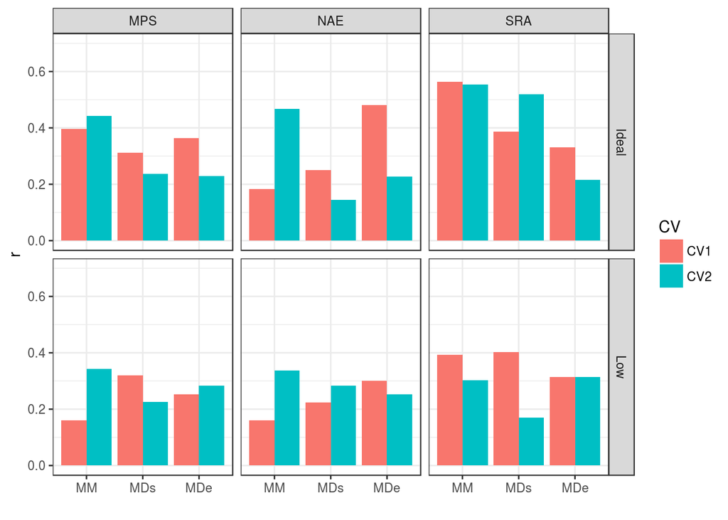

```r
ggplot(data=rgg, aes(x=Model, y=rgg,fill=CV)) +
      geom_bar(stat="identity",position=position_dodge())+
  ylab("r")+xlab(" ")+scale_y_continuous(limits = c(0, 0.7))+
  facet_grid(Environment~Trait,scales="free")+theme_bw()
```

- A capacidade preditiva dos modelos varia para cada caracteristica. Em geral, modelos para predição genômica de SRA exibiram capacidade preditiva superior à das demais caracteristicas.
- Comparando os esquemas CV1 e CV1, para cada caracteristica, é possível constatar que o modelo MM pode ser usado com elevada confiança par prediçõo de genótipos não amostrados em determinado ambiente.

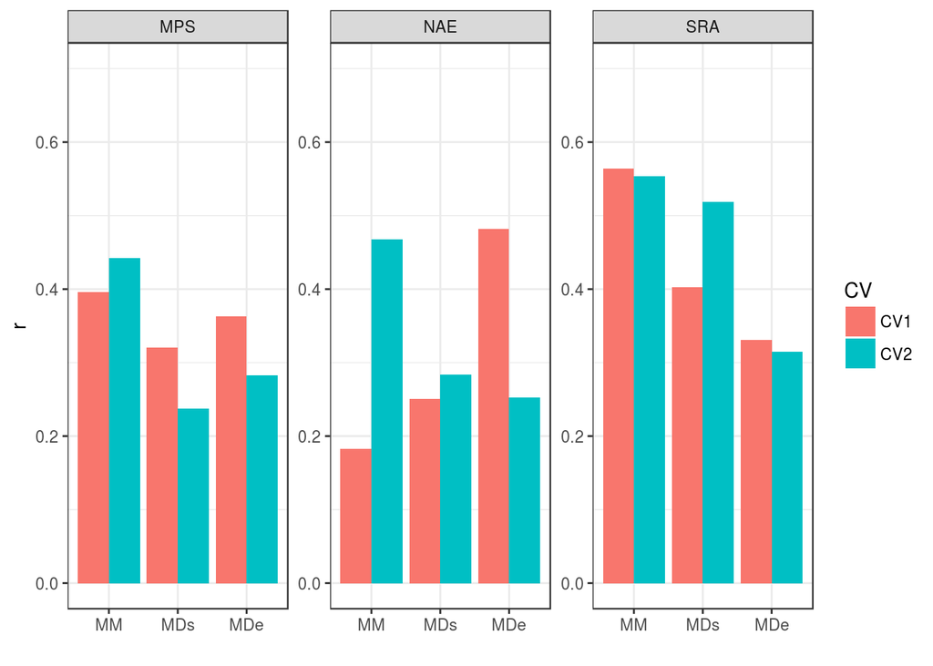

```r
ggplot(data=rgg, aes(x=Model, y=rgg,fill=CV)) +
      geom_bar(stat="identity",position=position_dodge())+
  ylab("r")+xlab(" ")+scale_y_continuous(limits = c(0, 0.7))+
  facet_wrap(~Trait,scales="free")+theme_bw()
```

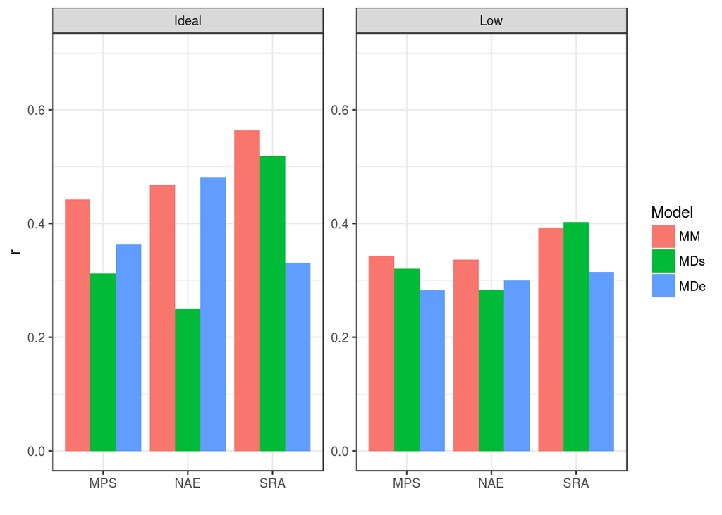

```r
ggplot(data=rgg, aes(x=Trait, y=rgg,fill=Model)) +
      geom_bar(stat="identity",position=position_dodge())+
  ylab("r")+xlab(" ")+scale_y_continuous(limits = c(0, 0.7))+
  facet_wrap(~Environment,scales="free")+theme_bw()
```